## Impact of Minimum Wage Increase on Income and Consumption

By Jessica Kim

March 21, 2018

How does income and consumption respond to an increase in minimum wage?

The intent of the US minimum wage policy is to provide economic assistance to low income households by setting a minimum wage that must be paid by employers to minimum wage employees. Whether this policy is effective is a question of interest and one that has been a topic of long debate.

The following are the study hypotheses:

**Hypotheses**

*An increase in minimum wage will allow more income and consumption for younger, lower economic status household heads.*

*Older and higher economic household heads’ income and consumption will not be affected by the minimum wage increase.*

### Sample

This research looks at two samples that differ in income separately for the analysis

-The LOW group in this study are defined as workers who are under the age 30 and who have non-managerial jobs.

-The HIGH group is defined as workers who are ages 30+ who are not retired. See appendix for income and wage distributions.

### Method

In this study, the increase in minimum wage is the policy intervention and the change in log income and change in log consumption are separate outcome variables that may be affected by the policy. To identify that there is a causal relationship rather than a correlational one between income (consumption) and the policy intervention, this study conducts a state-level analyses of U.S. income and consumption data using a two-way fixed effects regression analysis. This resembles the “differences-in-differences” approach by taking advantage of the state variation in minimum wage increase and comparing the pre and post policy intervention time periods for each of the treatment and control states. The difference is that in the two-way fixed effects approach, there are multiple time periods within both pre and post the treatment. Also, the two-way fixed effects approach assumes that the treatment effect is constant.

### Data

The income and spending data in this study is a repeated cross sections data set from the Conspicuous Consumption and Race paper by Charles et al (2008). Their original data is from Consumer Expenditure Survey (CEX) Family-Level Extracts which was compiled by Harris and Sabelhaus (2000), NBER. Harris and Sabelhaus (2000) compiled data from the quarterly Interview Survey and weekly Diary survey of the CEX survey by the Bureau of Labor Statistics.The author calculates the annual consumption data by multiplying the per quarter spending by four. The original data is at the household level across the span of 1986 to 2003. However, because the data is a repeated cross-sectional data set, with each household appearing only once in the data set, there is no within household variation that can be identified. Therefore, this paper’s analysis collapses the data to the state level to make a pseudo panel data set, where now the average state-level amount for each variable is observed repeatedly over time. To measure minimum wage, this study merges in minimum wage historical data from the Tax Policy Center of the Brookings Institution. Due to missing data in the merged data set, the final number of states available for analysis is a total of 39 states.

### Models

1. To measure the immediate effect of the treatment, assuming minimum wage increase takes effect at the beginning of the year:

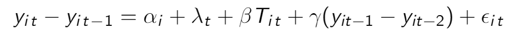

where i = state, t= year, y= log income or y= log total consumption,$\alpha _i$ is state fixed effects, $\lambda_t$ is year fixed effects, $\beta$ is the average treatment effect. $\gamma$ is the coefficient for the lag outcome variable.

2. However, given that the minimum wage increase may not affect log income (consumption) immediately, I also measure the long-term effect:

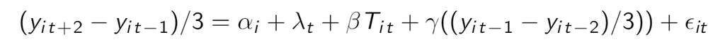

The treatment is defined in three separate ways to provide robustness check of how the minimum wage increase treatment is defined.

Treatments: 1. binary treatment if there was any minimum wage increase 2. continuous variable treatment of state minimum wage. For the continuous treatment, the regression is

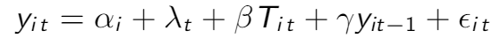

3. Binary treatment for only minimum wage shocks where the increased amount is at least 30 percent or more than the previous year’s minimum wage. These shocks only occurred 14 times in the data.

There are potential covariates that can be added that impact change in income growth. State GDP and state taxes are some examples. These vary across states and impact income growth. The fixed effects may be able to control for these if we assume that these omitted covariates also have a linear relationship with income growth. It is hard to argue that growth in state GDP is linear, therefore adding it as a covariate may be a stronger analysis. For change in consumption growth, potential good covariates would be change in state interest rates and change in inflation rates. As these variables are not readily available in the data, I plan to include these in the future. Being in certain racial groups may change the propensity to consume or earn. However, I think the racial population levels in states will not change quickly over time, and therefore, can be controlled by state and year fixed effects.

#### Parallel Trend Assumption

A core assumption is that the treatment and control group have parallel trends in the outcome variable prior to the treatment. In this data, the treatment occurs at different times for different states, therefore the existence of parallel trends is validated through observing if there is a correlation between the change in the outcome variable during the pretreatment period with the date of entry of the treatment. If there is no correlation between the variables, then this shows that the identification is valid and there is a parallel trend between the treatment and control states. The parallel trend assumption is validated as there is no statistically significant relationship between the year of minimum wage increase with the pretreatment trend in change of log income (consumption).

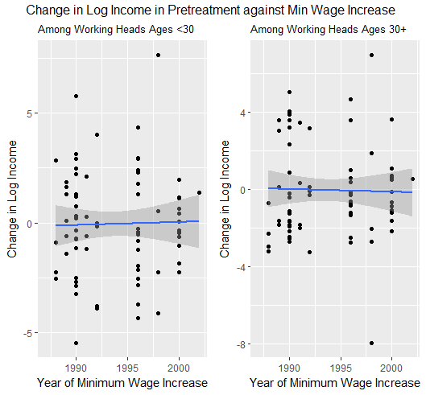

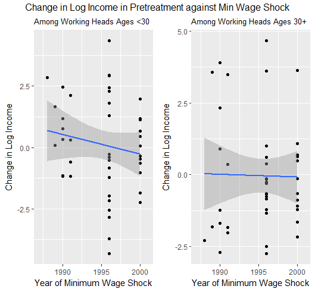

### Results

From all three treatment definitions, I cannot find a significant immediate or long term effect of minimum wage increase on change in log income nor change in log consumption for the low income group, which suggests that the minimum wage policy does not work.

In the main results here, I only show results for the binary treatment for any minimum wage increase (Treatment 1). The other two treatment definition results are shown in the appendix.

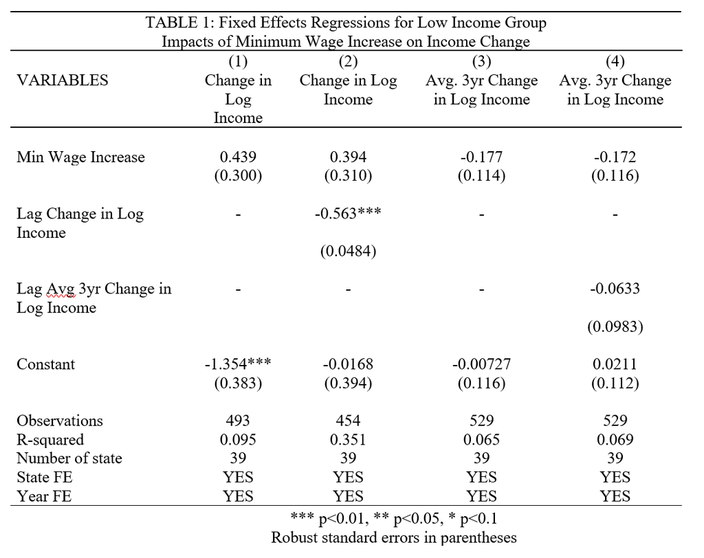

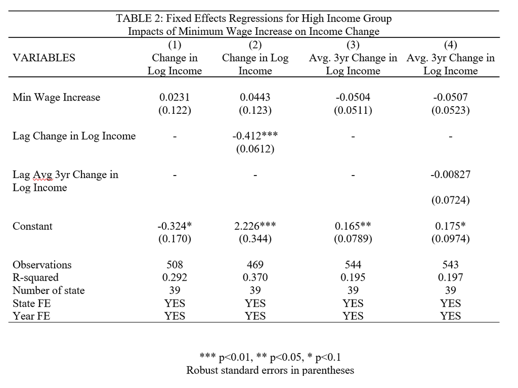

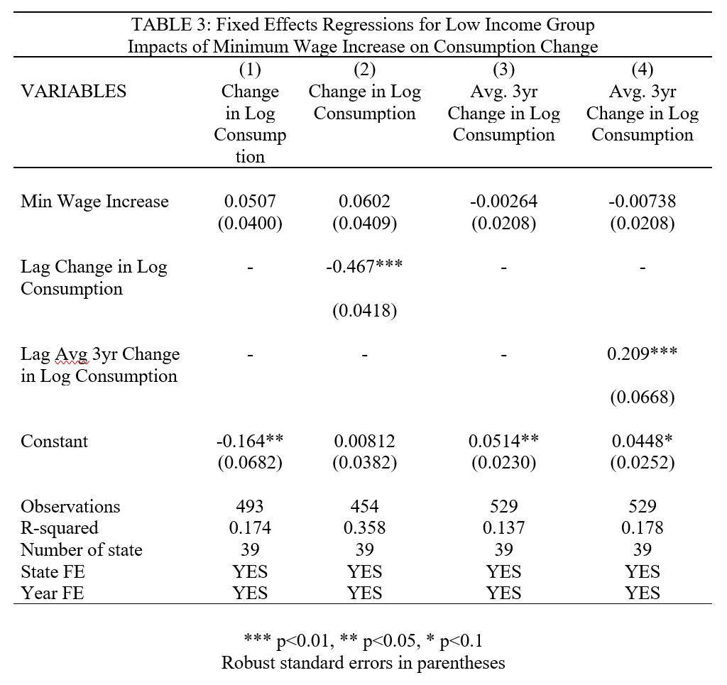

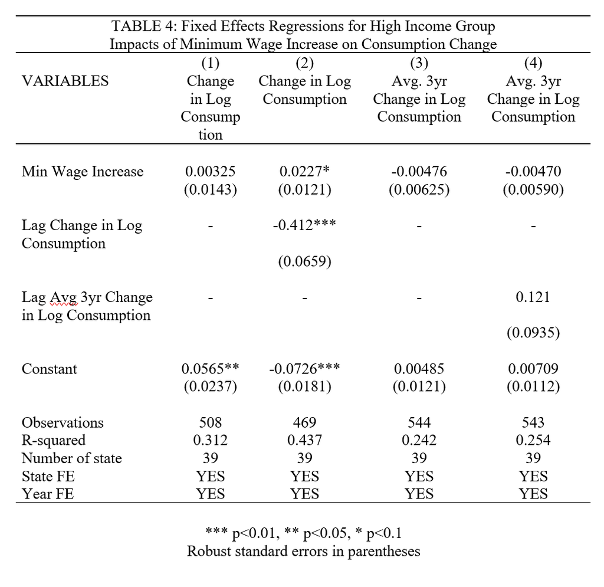

### Conclusion

Based on these preliminary results, this research shows that the minimum wage policy is ineffective. However, this research has some limitations. First, there are only 39 states in the analysis. Having more data would help. Also, the research may suffer from omitted variable bias. Adding the aforementioned covariates once obtaining data for them may change the analysis.

### Appendix

#### Income and Wage Distributions

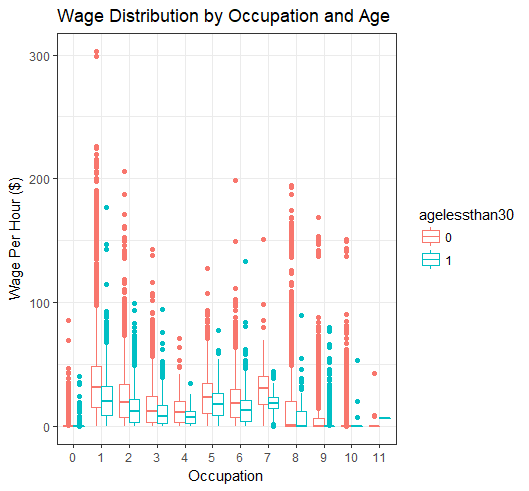

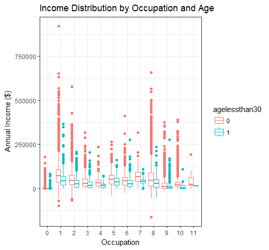

Graph x-axis occupation Legend: 01=managerial and professional specialty occupation, 02=technical, sales, and administrative support, 03=service, 04=farming, forestry, and fishing; 05=precision production, craft, and repair; 06=operators, fabricators, and laborers; 07=armed forces, 08=self employed, 09=not working, 10=retired; 0, 11=other, including not reported.

#### Tables for Min Wage Impact on Change in Log Income

##### Treatment 2 (Continuous State Minimum Wage as regressor)

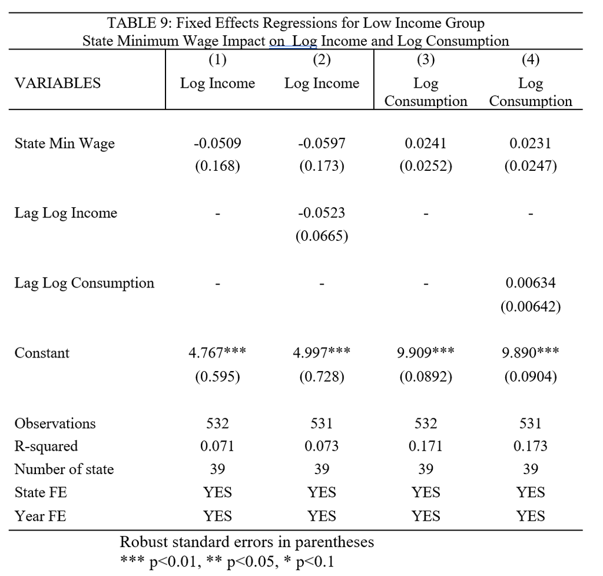

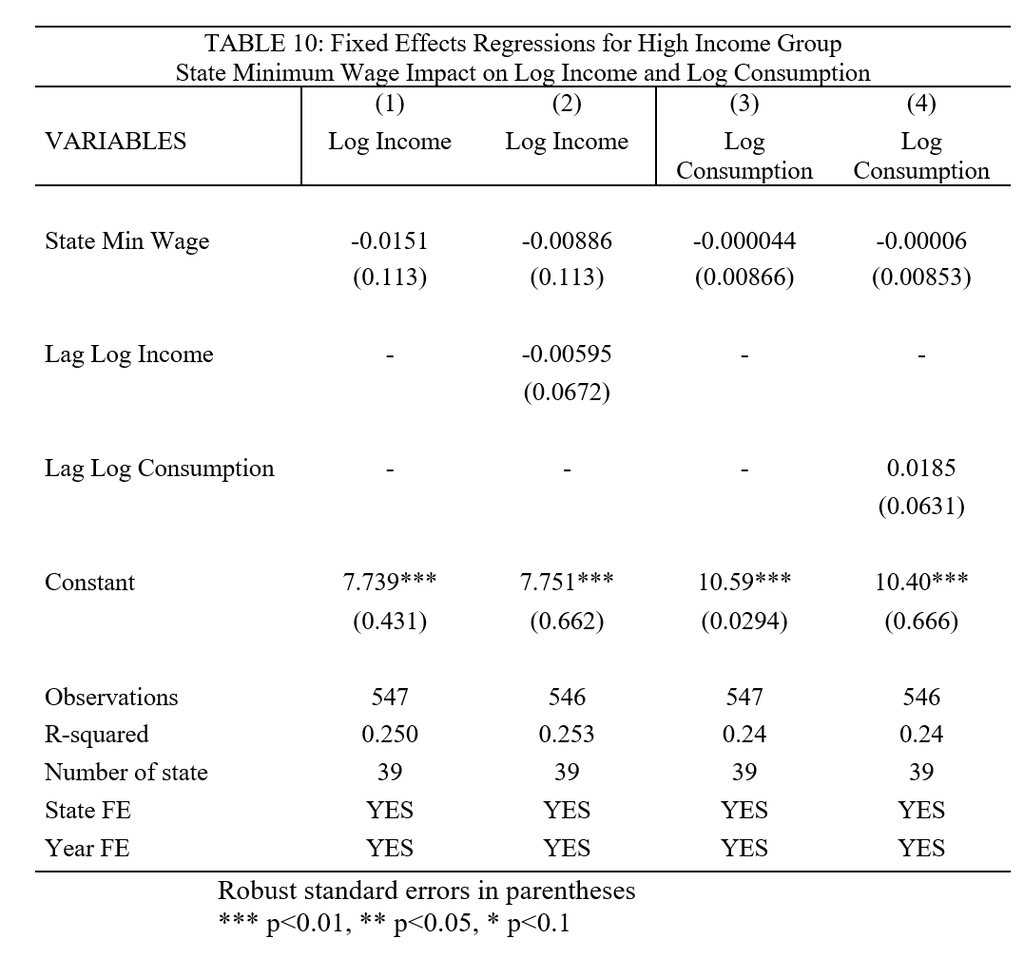

#### Treatment 3 (Minimum Wage Shocks as regressor)

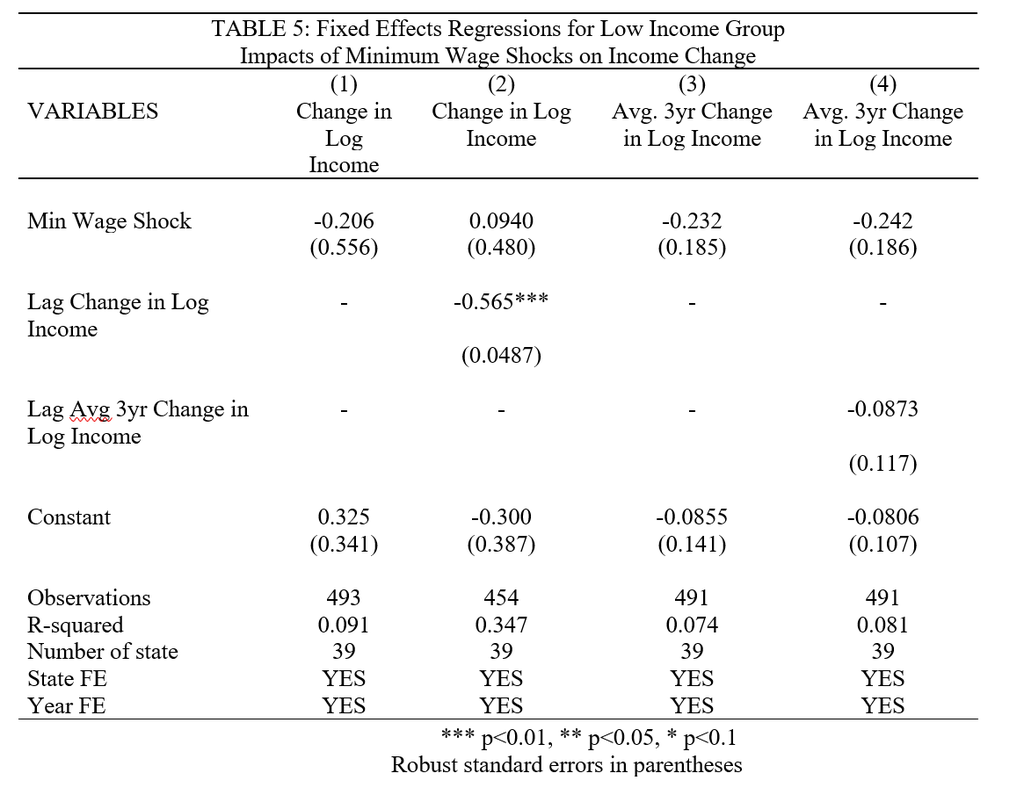

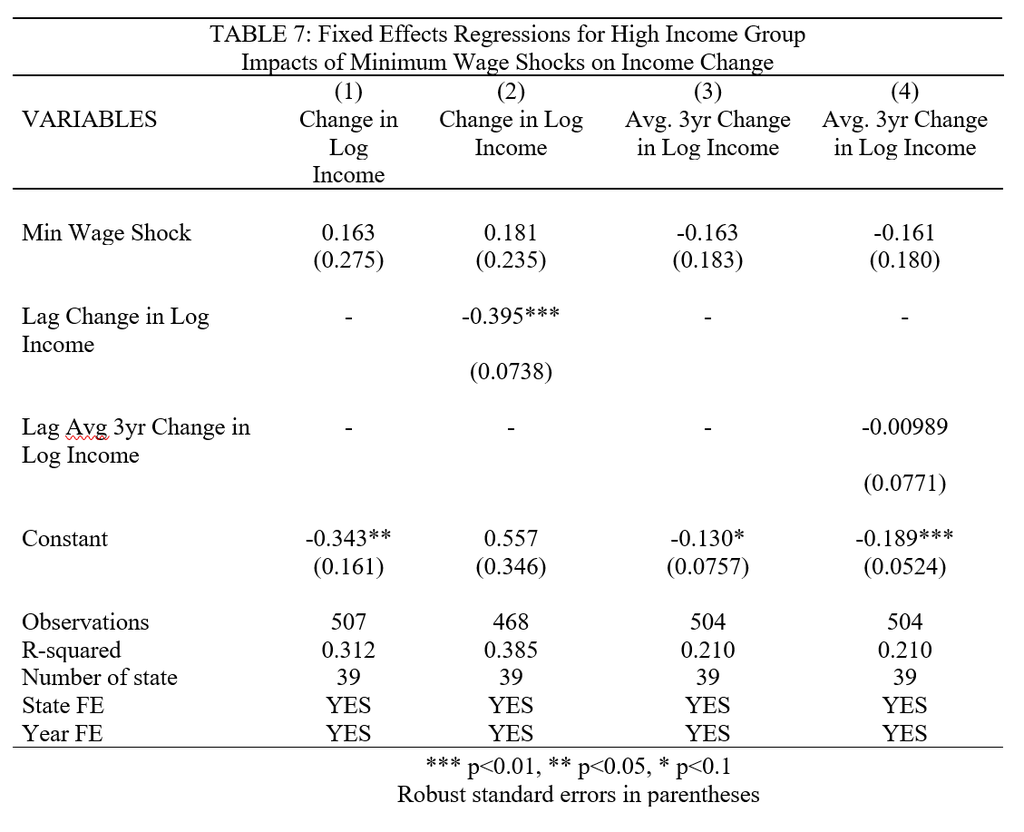

#### Tables for Min Wage Impact on Change in Log Consumption

##### Treatment 3 (Minimum Wage Shocks as regressor)

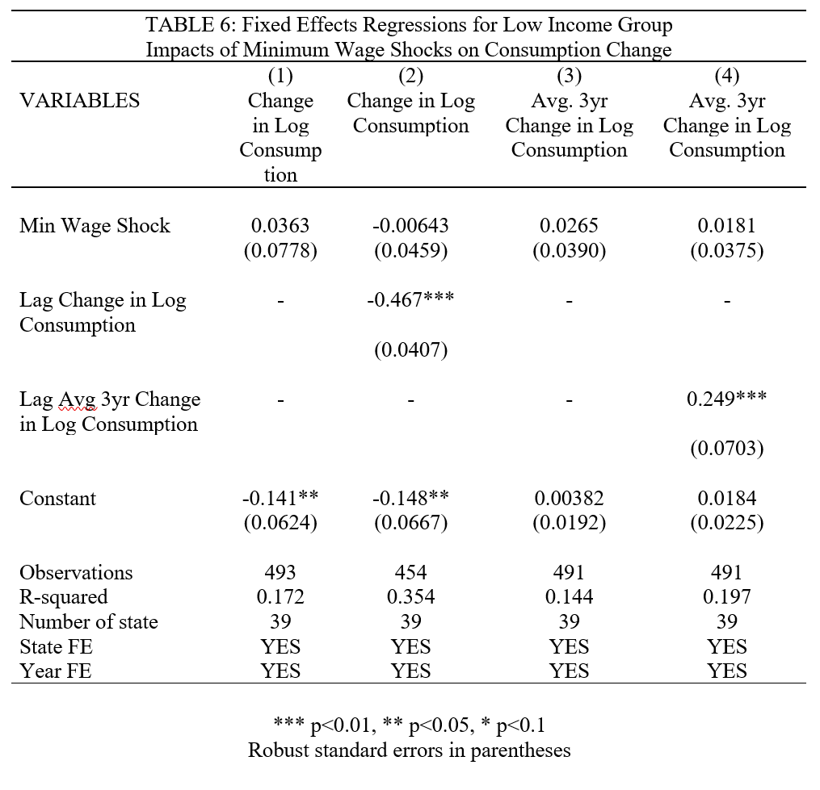

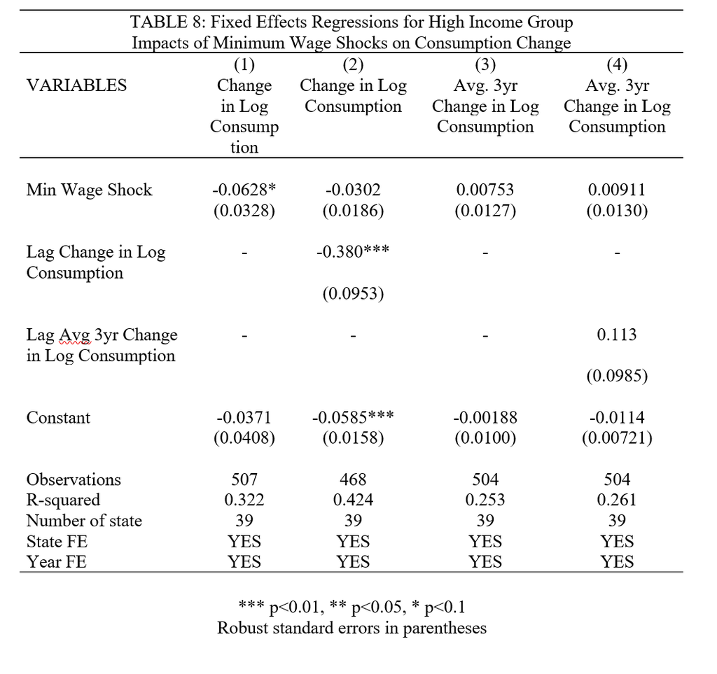